# Voting System using NSL-KDDD dataset for SIEM/IDS systems

It's a system that combines three indepedant neural networks and fuses their output according to a voting system which follows the majority-rules process! The model was developed using the [NSL-KDD](https://www.unb.ca/cic/datasets/index.html) dataset, which is an improved version of its predecssor [KDD'99](http://kdd.ics.uci.edu/databases/kddcup99/kddcup99.html) dataset.

The initial pre-processing steps (Preperating The Environement) were insipred from the following [code](https://github.com/thinline72/nsl-kdd).

## Preparing The Environement

```python
import numpy as np
import pandas as pd

## label encoder
from sklearn.preprocessing import LabelEncoder

## for plotting
import matplotlib.pyplot as plt
```

Next, we will load the different of the dataset and the indices of the nominal and numerical features in the training/test set.

```python
train_nsl_kdd_dataset_path = "/Path_To_File/KDDTrain+.txt"
test_nsl_kdd_dataset_path = "/Path_To_File/KDDTest+.txt"

col_names = np.array(["duration","protocol_type","service","flag","src_bytes",
    "dst_bytes","land","wrong_fragment","urgent","hot","num_failed_logins",
    "logged_in","num_compromised","root_shell","su_attempted","num_root",
    "num_file_creations","num_shells","num_access_files","num_outbound_cmds",
    "is_host_login","is_guest_login","count","srv_count","serror_rate",
    "srv_serror_rate","rerror_rate","srv_rerror_rate","same_srv_rate",
    "diff_srv_rate","srv_diff_host_rate","dst_host_count","dst_host_srv_count",
    "dst_host_same_srv_rate","dst_host_diff_srv_rate","dst_host_same_src_port_rate",
    "dst_host_srv_diff_host_rate","dst_host_serror_rate","dst_host_srv_serror_rate",
    "dst_host_rerror_rate","dst_host_srv_rerror_rate","labels"])

nominal_inx = [1, 2, 3]
binary_inx = [6, 11, 13, 14, 20, 21]
numeric_inx = list(set(range(41)).difference(nominal_inx).difference(binary_inx))

nominal_cols = col_names[nominal_inx].tolist()
binary_cols = col_names[binary_inx].tolist()
numeric_cols = col_names[numeric_inx].tolist()
```

Whether we will be using binary classification or multi-class classification, we will need a a dictionnary that will map the output

```python
# Dictionary that contains mapping of various attacks to the four main categories
attack_dict = {
    'normal': 'normal',

    'back': 'DoS',
    'land': 'DoS',
    'neptune': 'DoS',
    'pod': 'DoS',
    'smurf': 'DoS',
    'teardrop': 'DoS',
    'mailbomb': 'DoS',
    'apache2': 'DoS',
    'processtable': 'DoS',
    'udpstorm': 'DoS',

    'ipsweep': 'Probe',
    'nmap': 'Probe',
    'portsweep': 'Probe',
    'satan': 'Probe',
    'mscan': 'Probe',
    'saint': 'Probe',

    'ftp_write': 'R2L',
    'guess_passwd': 'R2L',
    'imap': 'R2L',
    'multihop': 'R2L',
    'phf': 'R2L',
    'spy': 'R2L',
    'warezclient': 'R2L',
    'warezmaster': 'R2L',
    'sendmail': 'R2L',
    'named': 'R2L',
    'snmpgetattack': 'R2L',
    'snmpguess': 'R2L',
    'xlock': 'R2L',
    'xsnoop': 'R2L',
    'worm': 'R2L',

    'buffer_overflow': 'U2R',
    'loadmodule': 'U2R',
    'perl': 'U2R',
    'rootkit': 'U2R',
    'httptunnel': 'U2R',
    'ps': 'U2R',
    'sqlattack': 'U2R',
    'xterm': 'U2R'
}
```

## Data manipulation

In this phase, we will devide the dataset into 3 parts (train, validation and test). We will also seperate the input from the output labels.

```python
import torch
import torch.utils.data
cols = list(range(0, 42))
train = pd.read_csv(train_nsl_kdd_dataset_path, sep=",", names = col_names, usecols = cols)
test = pd.read_csv(test_nsl_kdd_dataset_path, sep=",", names = col_names, usecols = cols)

# Splitting Data into train and validation (80% Training and 20% Validation)
train_size = int(0.8 * len(train))
validation_size = len(train) - train_size
Training_Set, Validation_Set = torch.utils.data.random_split(train, [train_size, validation_size])

# Train data
Y_train  = pd.DataFrame(Training_Set.dataset.iloc[Training_Set.indices]['labels'])
X_train = Training_Set.dataset.iloc[Training_Set.indices].drop(columns="labels")

# Validation data
Y_val  = pd.DataFrame(Validation_Set.dataset.iloc[Validation_Set.indices]['labels'])
X_val = Validation_Set.dataset.iloc[Validation_Set.indices].drop(columns="labels")

# Test data
Y_test  = pd.DataFrame(test['labels'])
X_test = test.drop(columns="labels")

print("Shape of X_train is ", X_train.shape, "shape of target", Y_train.shape)
print("Shape of X_val is ", X_val.shape, "shape of target", Y_val.shape)
print("Shape of X_test is ", X_test.shape, "shape of target", Y_test.shape)
```

```
Shape of X_train is  (100778, 41) shape of target (100778, 1)
Shape of X_val is  (25195, 41) shape of target (25195, 1)
Shape of X_test is  (22544, 41) shape of target (22544, 1)
```

```python
X_train.head()
```

|  | duration | protocol_type | service | flag | src_bytes | dst_bytes | land | wrong_fragment | urgent | hot | num_failed_logins | logged_in | num_compromised | root_shell | su_attempted | num_root | num_file_creations | num_shells | num_access_files | num_outbound_cmds | is_host_login | is_guest_login | count | srv_count | serror_rate | srv_serror_rate | rerror_rate | srv_rerror_rate | same_srv_rate | … |
| --- | --- | --- | --- | --- | --- | --- | --- | --- | --- | --- | --- | --- | --- | --- | --- | --- | --- | --- | --- | --- | --- | --- | --- | --- | --- | --- | --- | --- | --- | --- |
| 105385 | 0 | tcp | http | SF | 295 | 1215 | 0 | 0 | 0 | 0 | 0 | 1 | 0 | 0 | 0 | 0 | 0 | 0 | 0 | 0 | 0 | 0 | 14 | 16 | 0.0 | 0.0 | 0.0 | 0.0 | 1.0 | … |
| 83300 | 0 | tcp | ftp_data | SF | 1109 | 0 | 0 | 0 | 0 | 0 | 0 | 1 | 0 | 0 | 0 | 0 | 0 | 0 | 0 | 0 | 0 | 0 | 1 | 1 | 0.0 | 0.0 | 0.0 | 0.0 | 1.0 | … |
| 113207 | 0 | icmp | ecr_i | SF | 1032 | 0 | 0 | 0 | 0 | 0 | 0 | 0 | 0 | 0 | 0 | 0 | 0 | 0 | 0 | 0 | 0 | 0 | 228 | 228 | 0.0 | 0.0 | 0.0 | 0.0 | 1.0 | … |
| 33036 | 0 | udp | domain_u | SF | 55 | 108 | 0 | 0 | 0 | 0 | 0 | 0 | 0 | 0 | 0 | 0 | 0 | 0 | 0 | 0 | 0 | 0 | 2 | 2 | 0.0 | 0.0 | 0.0 | 0.0 | 1.0 | … |
| 31107 | 0 | udp | private | SF | 28 | 0 | 0 | 3 | 0 | 0 | 0 | 0 | 0 | 0 | 0 | 0 | 0 | 0 | 0 | 0 | 0 | 0 | 80 | 80 | 0.0 | 0.0 | 0.0 | 0.0 | 1.0 | … |

```python
X_train['flag'].value_counts()
```

```
SF        59950
S0        27846
REJ        9029
RSTR       1924
RSTO       1258
S1          292
SH          219
S2          101
RSTOS0       80
S3           40
OTH          39
Name: flag, dtype: int64
```

Now, we will create to types of fata for Binary classification and Multi-class classification

```python
# 5 Classes dataset

Y_train5 = Y_train.copy()
Y_train5['labels'] = Y_train5['labels'].map(attack_dict)

Y_val5 = Y_val.copy()
Y_val5['labels'] = Y_val5['labels'].map(attack_dict)

Y_test5 = Y_test.copy()
Y_test5['labels'] = Y_test5['labels'].map(attack_dict)
```

```python
Y_test5.head()
```

|  | labels |
| --- | --- |
| 0 | DoS |
| 1 | DoS |
| 2 | normal |
| 3 | Probe |
| 4 | Probe |

```python
# 2 Classes dataset

import re

Y_train2 = Y_train.copy()
Y_train2['labels'] = Y_train2['labels'].map({v : re.sub('^(?!normal).*$', 'attack', k) for  v, k in attack_dict.items()})

Y_val2 = Y_val.copy()
Y_val2['labels'] = Y_val2['labels'].map({v : re.sub('^(?!normal).*$', 'attack', k) for  v, k in attack_dict.items()})

Y_test2 = Y_test.copy()
Y_test2['labels'] = Y_test2['labels'].map({v : re.sub('^(?!normal).*$', 'attack', k) for  v, k in attack_dict.items()})
```

```python
Y_test2.head()
```

|  | labels |
| --- | --- |
| 0 | attack |
| 1 | attack |
| 2 | normal |
| 3 | attack |
| 4 | attack |

```python
#Y_train5['labels'].value_counts()
#Y_test5['labels'].value_counts()

#Y_train2['labels'].value_counts()
Y_test2['labels'].value_counts()
```

```
attack    12833
normal     9711
Name: labels, dtype: int64
```

## Feature Selection & Feature Encoding & Normalization

First, we'll remove features that were found to be unnecessary in some research articles.

```python
X_train_copy = X_train.copy()
X_val_copy = X_val.copy()
X_test_copy = X_test.copy()
```

```python
remove_indices = [7, 8, 9, 11, 14, 15, 17, 19, 20, 21, 32, 40]
print("Indices to remove: ", remove_indices)

cols_to_remove = col_names[remove_indices].tolist()

X_train_remove = X_train_copy.drop(columns = cols_to_remove)
X_val_remove = X_val_copy.drop(columns = cols_to_remove)
X_test_remove = X_test_copy.drop(columns = cols_to_remove)

features = [i for j, i in enumerate(col_names) if j not in remove_indices]
features.pop()
```

```
Indices to remove:  [7, 8, 9, 11, 14, 15, 17, 19, 20, 21, 32, 40]
```

[output not shown]

```python
from sklearn.compose import ColumnTransformer
from sklearn.preprocessing import Normalizer
from sklearn.preprocessing import OneHotEncoder
from sklearn import preprocessing

# Encode the data

ct_new = ColumnTransformer([
    ("onehot", OneHotEncoder(handle_unknown='ignore'), nominal_cols),
], remainder='passthrough')

X_train_papers = pd.DataFrame((ct_new.fit_transform(X_train_remove)).toarray())
X_val_papers = pd.DataFrame((ct_new.transform(X_val_remove)).toarray())
X_test_papers = pd.DataFrame((ct_new.transform(X_test_remove)).toarray())
```

```python
# And then we normalize the data

scalerr = preprocessing.StandardScaler().fit(X_train_papers)

X_train_scaled = scalerr.transform(X_train_papers)
X_val_scaled = scalerr.transform(X_val_papers)
X_test_scaled = scalerr.transform(X_test_papers)

print("Done !")
```

```
Done !
```

```python
X_train_scaled.shape
```

```
(100778, 109)
```

## Principal component analysis (PCA)

```python
from sklearn.decomposition import PCA

# We apply PCA data after feature extraction

my_PCA = PCA(n_components=90) # 99% Variance retained
my_PCA.fit(X_train_scaled)

X_train_PCA = my_PCA.transform(X_train_scaled)
X_val_PCA = my_PCA.transform(X_val_scaled)
X_test_PCA = my_PCA.transform(X_test_scaled)

#print(my_PCA.explained_variance_)
#print(my_PCA.explained_variance_ratio_)
print(my_PCA.explained_variance_ratio_.cumsum())
("Done !", X_train_PCA.shape)
```

```
[0.08002966 0.12681414 0.15968486 0.18640701 0.20650384 0.22513801
 0.24074832 0.2548583  0.26788895 0.27928882 0.29018296 0.30097618
 0.31170075 0.32224512 0.3326961  0.34301534 0.35276842 0.36232579
 0.37176109 0.38111812 0.39045657 0.39973862 0.40901626 0.41826022
 0.42749935 0.4367337  0.44596146 0.45518777 0.46441359 0.47363816
 0.48286104 0.49208156 0.50130088 0.51051899 0.51973657 0.52895204
 0.53816733 0.54738126 0.55659432 0.56580624 0.57501754 0.58422831
 0.59343803 0.60264756 0.61185624 0.62106404 0.6302716  0.63947877
 0.64868522 0.65789129 0.66709574 0.67629966 0.68550268 0.69470394
 0.70390443 0.71310383 0.72230219 0.7314999  0.74069294 0.74987816
 0.75906219 0.76824299 0.77742323 0.78660309 0.79577987 0.80495593
 0.81413154 0.82330663 0.8324815  0.841656   0.8508302  0.86000288
 0.86916997 0.878317   0.88743721 0.89647383 0.90547278 0.91424465
 0.92259725 0.93078023 0.93840697 0.94569563 0.95198907 0.95808482
 0.96353957 0.96839102 0.97320684 0.9774537  0.98135633 0.98482287]
```

```
('Done !', (100778, 90))
```

Now we prepare labels for binary and multi-class classification

```python
# Binary Classification

ct_2 = ColumnTransformer([
    ("onehot", OneHotEncoder(handle_unknown='ignore'), ['labels']),
], remainder='passthrough')

#Y_train2 = pd.DataFrame(ct_2.fit_transform(Y_train2), columns = ct_2.get_feature_names())
#Y_test2 = pd.DataFrame(ct_2.transform(Y_test2), columns = ct_2.get_feature_names())

Y_train2 = Y_train2.replace('normal', 0)
Y_train2 = Y_train2.replace('attack', 1)

Y_val2 = Y_val2.replace('normal', 0)
Y_val2 = Y_val2.replace('attack', 1)

Y_test2 = Y_test2.replace('normal', 0)
Y_test2 = Y_test2.replace('attack', 1)

# Multi-class Classification

ct_5 = ColumnTransformer([
    ("onehot", OneHotEncoder(handle_unknown='ignore'), ['labels']),
], remainder='passthrough')

Y_train5 = pd.DataFrame(ct_5.fit_transform(Y_train5).toarray(), columns = ct_5.get_feature_names())

Y_val5 = pd.DataFrame(ct_5.fit_transform(Y_val5).toarray(), columns = ct_5.get_feature_names())

Y_test5 = pd.DataFrame(ct_5.transform(Y_test5).toarray(), columns = ct_5.get_feature_names())

print("Done !")
```

```
Done !
```

# Neural Networks / Base learners

Now we will create the neural networks which we will combine in the final model. We have used the library pytorch. Each neural network has a different structure, architecture and parameters. We have also used a modified version of the drop-out regularization to create weak neural networks. Please read our [paper](https://www.hindawi.com/journals/scn/2020/3512737/) for more information.

```python
from torch.utils.data import TensorDataset
from torch.utils.data import DataLoader

# Hyper-parameters of the first neural network
data_size, input_size = X_train_PCA.shape
num_classes = 1
num_epochs = 15

remove_percentage = 0.67

# convert the data arrays into torch tensors
Xtrain_PCA = torch.from_numpy(X_train_PCA).float()
Ytrain = torch.from_numpy(Y_train2.to_numpy()).float()

Xval_PCA = torch.from_numpy(X_val_PCA).float()
Yval = torch.from_numpy(Y_val2.to_numpy()).float()

Xtest_PCA = torch.from_numpy(X_test_PCA).float()
Ytest = torch.from_numpy(Y_test2.to_numpy()).float()
```

Define the first neural network

```python
# Fully connected neural network with one hidden layer
class NeuralNet(torch.nn.Module):
    def __init__(self, input_size, hidden_size, num_classes, remove_percentage, order):
        super(NeuralNet, self).__init__()
        self.order = order
        self.fc1 = torch.nn.Linear(input_size, hidden_size)
        self.relu = torch.nn.ReLU()
        self.fc2 = torch.nn.Linear(hidden_size, num_classes)
        self.log_soft = torch.nn.Sigmoid()

    def forward(self, x):
        if self.training:
            out = self.train_module(x, self.order)
            out = self.fc1(out)
            out = self.relu(out)
            out = self.fc2(out)
            out = self.log_soft(out)
        else:
            out = self.fc1(x)
            out = self.relu(out)
            out = self.fc2(out)
            out = self.log_soft(out)
        return out

    def train_module(self, input_data, order):
        # This function will remove remove_percentage % of features
        # Order is the rank of features to remove
        out = input_data.clone()

        keep_percentage = round(1 - remove_percentage, 2)
        removing_step = round(input_size * keep_percentage)

        for i in range(input_size):
            if i in range((order - 1) * removing_step, order * removing_step):
                out[:, i] /= keep_percentage
            else:
                out[:, i] = 0.0
        return out

seed_value = 10 # some number that you manually pick
torch.manual_seed(seed_value)
```

```
<torch._C.Generator at 0x7f9f0f9b0cd0>
```

```python
from torch.autograd import Variable

# define the training procedure
# i.e. one step of gradient descent
# there are lots of steps
# so we encapsulate it in a function
# Note: inputs and labels are torch tensors

def train(model, criterion, optimizer, inputs, labels):

    inputs = Variable(inputs, requires_grad=False)
    labels = Variable(labels, requires_grad=False)

    model.train()

    # Forward pass
    outputs = model(inputs)
    loss = criterion(outputs, labels)

    # Backward and optimize
    optimizer.zero_grad()
    loss.backward()
    optimizer.step()

    return loss.item()

# similar to train() but not doing the backprop step
def get_cost(model, criterion, inputs, labels):

    inputs = Variable(inputs, requires_grad=False)
    labels = Variable(labels, requires_grad=False)

    model.eval()
    # Forward
    outputs = model(inputs)
    loss = criterion(outputs, labels)

    return loss.item()
```

```python
from sklearn.metrics import accuracy_score
from sklearn.metrics import classification_report

# define the prediction procedure
def predict(model, inputs):

    model.eval()
    prediction = model(inputs)
    prediction = (prediction > 0.5)

    return prediction

# return the accuracy
def my_score(model, inputs, labels):
    prediction = predict(model, inputs)
    return (classification_report(labels, prediction, target_names=['Normal', 'Attack']))

# return the full performance metrics
def get_accuracy(model, inputs, labels):
    prediction = predict(model, inputs)
    return accuracy_score(labels, prediction)
```

```python
order = 1 # The first 30 features will be keeped
hidden_size = 10
model1 = NeuralNet(input_size, hidden_size, num_classes, remove_percentage, order)



# Loss and optimizer
criterion1 = torch.nn.BCELoss()
optimizer1 = torch.optim.SGD(model1.parameters(), lr= 0.003)


# Use a DataLoader to manage batches
bs = 256 # batch size
train_ds = TensorDataset(Xtrain_PCA, Ytrain)
valid_ds = TensorDataset(Xval_PCA, Yval)

train_dl = DataLoader(train_ds, batch_size=bs, shuffle=True)
valid_dl = DataLoader(valid_ds, batch_size=bs * 2)



# things to keep track of
train_costs = []
validation_costs = []
train_accuracies = []
validation_accuracies = []

print("Training the first neural network...")

# main training loop
for i in range(num_epochs): # Number of epochs
    cost = 0
    val_cost = 0
    for xb,yb in train_dl:
        cost += train(model1, criterion1, optimizer1, xb, yb)

    train_acc = get_accuracy(model1, Xtrain_PCA, Ytrain)
    val_acc = get_accuracy(model1, Xval_PCA, Yval)
    val_cost = get_cost(model1, criterion1, Xval_PCA, Yval)
    test_acc = get_accuracy(model1, Xtest_PCA, Ytest)

    print("Epoch: %d, val_cost: %f, val_acc: %.4f, test_acc: %.4f" % (i, val_cost, val_acc, test_acc))

    # for plotting
    train_costs.append(cost / len(train_dl))
    train_accuracies.append(train_acc)
    validation_costs.append(val_cost)
    validation_accuracies.append(val_acc)
#    if (round(val_cost, 3) <= 0.3):
#      break
print("Training is done")
```

```
Training the first neural network...
Epoch: 0, val_cost: 0.459552, val_acc: 0.9213, test_acc: 0.7652
Epoch: 1, val_cost: 0.358524, val_acc: 0.9453, test_acc: 0.7560
Epoch: 2, val_cost: 0.318044, val_acc: 0.9495, test_acc: 0.7480
Epoch: 3, val_cost: 0.296283, val_acc: 0.9528, test_acc: 0.7425
Epoch: 4, val_cost: 0.282477, val_acc: 0.9573, test_acc: 0.7405
Epoch: 5, val_cost: 0.272478, val_acc: 0.9594, test_acc: 0.7390
Epoch: 6, val_cost: 0.264995, val_acc: 0.9608, test_acc: 0.7382
Epoch: 7, val_cost: 0.258708, val_acc: 0.9619, test_acc: 0.7375
Epoch: 8, val_cost: 0.253728, val_acc: 0.9628, test_acc: 0.7375
Epoch: 9, val_cost: 0.249622, val_acc: 0.9637, test_acc: 0.7361
Epoch: 10, val_cost: 0.245525, val_acc: 0.9639, test_acc: 0.7353
Epoch: 11, val_cost: 0.242197, val_acc: 0.9642, test_acc: 0.7340
Epoch: 12, val_cost: 0.239630, val_acc: 0.9660, test_acc: 0.7336
Epoch: 13, val_cost: 0.236335, val_acc: 0.9663, test_acc: 0.7332
Epoch: 14, val_cost: 0.233380, val_acc: 0.9663, test_acc: 0.7332
Training is done
```

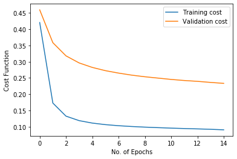

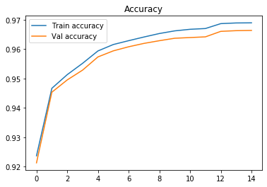

```python
# plot the results
plt.plot(train_costs, label='Training cost')
plt.plot(validation_costs, label='Validation cost')
plt.title('')
plt.xlabel('No. of Epochs')
plt.ylabel('Cost Function')
plt.legend()
plt.savefig("model1-trainval.png", dpi=300)
plt.show()

plt.plot(train_accuracies, label='Train accuracy')
plt.plot(validation_accuracies, label='Val accuracy')
plt.title('Accuracy')
plt.legend()
plt.show()
```

```python
test_report1 = my_score(model1, Xtest_PCA, Ytest)
test_cost1 = get_cost(model1, criterion1, Xtest_PCA, Ytest)
print(test_report1)
```

```
              precision    recall  f1-score   support

      Normal       0.63      0.92      0.75      9711
      Attack       0.91      0.59      0.72     12833

    accuracy                           0.73     22544
   macro avg       0.77      0.76      0.73     22544
weighted avg       0.79      0.73      0.73     22544
```

```python
order = 2 # The second 30 features will be keeped
hidden_size = 20
model2 = NeuralNet(input_size, hidden_size, num_classes, remove_percentage, order)


# Loss and optimizer
criterion2 = torch.nn.BCELoss()
optimizer2 = torch.optim.Rprop(model2.parameters(), lr = 3e-2)

# Use a DataLoader to manage batches
bs = data_size # batch size
train_ds = TensorDataset(Xtrain_PCA, Ytrain)
valid_ds = TensorDataset(Xval_PCA, Yval)

train_dl = DataLoader(train_ds, batch_size=bs, shuffle=True)
valid_dl = DataLoader(valid_ds, batch_size=bs * 2)

# things to keep track of
train_costs2 = []
validation_costs2 = []
train_accuracies2 = []
validation_accuracies2 = []

print("Training the second neural network...")

# main training loop
for i in range(num_epochs):
    cost = 0
    val_cost = 0
    for xb,yb in train_dl:
        cost += train(model2, criterion2, optimizer2, xb, yb)

    train_acc = get_accuracy(model2, Xtrain_PCA, Ytrain)
    val_acc = get_accuracy(model2, Xval_PCA, Yval)
    val_cost = get_cost(model2, criterion2, Xval_PCA, Yval)

    test_acc = get_accuracy(model2, Xtest_PCA, Ytest)

    print("Epoch: %d, val_cost: %f, val_acc: %.4f, test_acc: %.4f" % (i, val_cost, val_acc, test_acc))

    # for plotting
    train_costs2.append(cost / len(train_dl))
    train_accuracies2.append(train_acc)
    validation_costs2.append(val_cost)
    validation_accuracies2.append(val_acc)

print("Training is done")
```

```
Training the second neural network...
Epoch: 0, val_cost: 0.676735, val_acc: 0.6882, test_acc: 0.5707
Epoch: 1, val_cost: 0.653340, val_acc: 0.7059, test_acc: 0.6450
Epoch: 2, val_cost: 0.632073, val_acc: 0.7143, test_acc: 0.6762
Epoch: 3, val_cost: 0.609567, val_acc: 0.7403, test_acc: 0.6641
Epoch: 4, val_cost: 0.590167, val_acc: 0.7373, test_acc: 0.6847
Epoch: 5, val_cost: 0.571238, val_acc: 0.6300, test_acc: 0.5763
Epoch: 6, val_cost: 0.553349, val_acc: 0.6484, test_acc: 0.6164
Epoch: 7, val_cost: 0.540250, val_acc: 0.7080, test_acc: 0.6414
Epoch: 8, val_cost: 0.520787, val_acc: 0.7196, test_acc: 0.6400
Epoch: 9, val_cost: 0.504287, val_acc: 0.7099, test_acc: 0.6404
Epoch: 10, val_cost: 0.502979, val_acc: 0.7195, test_acc: 0.5958
Epoch: 11, val_cost: 0.469917, val_acc: 0.8143, test_acc: 0.6862
Epoch: 12, val_cost: 0.468464, val_acc: 0.7774, test_acc: 0.6544
Epoch: 13, val_cost: 0.456732, val_acc: 0.8232, test_acc: 0.6842
Epoch: 14, val_cost: 0.452915, val_acc: 0.8215, test_acc: 0.6735
Training is done
```

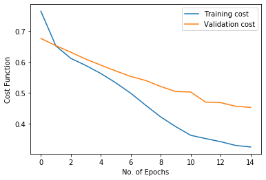

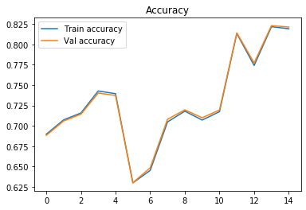

```python
# plot the results
plt.plot(train_costs2, label='Training cost')
plt.plot(validation_costs2, label='Validation cost')
plt.title('')
plt.xlabel('No. of Epochs')
plt.ylabel('Cost Function')
plt.legend()
plt.savefig("model2-trainval.png", dpi=300)
plt.show()

plt.plot(train_accuracies2, label='Train accuracy')
plt.plot(validation_accuracies2, label='Val accuracy')
plt.title('Accuracy')
plt.legend()
plt.show()
```

```python
test_report2 = my_score(model2, Xtest_PCA, Ytest)
test_cost2 = get_cost(model2, criterion2, Xtest_PCA, Ytest)
print(test_report2)
```

```
              precision    recall  f1-score   support

      Normal       0.58      0.88      0.70      9711
      Attack       0.85      0.51      0.64     12833

    accuracy                           0.67     22544
   macro avg       0.72      0.70      0.67     22544
weighted avg       0.74      0.67      0.67     22544
```

Tuning the third neural network

```python
order = 3 # The third 30 features will be keeped
hidden_size = 15
model3 = NeuralNet(input_size, hidden_size, num_classes, remove_percentage, order)

# Loss and optimizer
criterion3 = torch.nn.BCELoss()
optimizer3 = torch.optim.Adam(model3.parameters(), lr = 1e-4, amsgrad=True)

#######################################################################################

# Use a DataLoader to manage batches
bs = 512 # batch size
train_ds = TensorDataset(Xtrain_PCA, Ytrain)
valid_ds = TensorDataset(Xval_PCA, Yval)

train_dl = DataLoader(train_ds, batch_size=bs, shuffle=True)
valid_dl = DataLoader(valid_ds, batch_size=bs * 2)

# things to keep track of
train_costs3 = []
validation_costs3 = []
train_accuracies3 = []
validation_accuracies3 = []

print("Training the third neural network...")

# main training loop
for i in range(num_epochs): # Number of epochs
    cost = 0
    val_cost = 0
    for xb,yb in train_dl:
        cost += train(model3, criterion3, optimizer3, xb, yb)

    train_acc = get_accuracy(model3, Xtrain_PCA, Ytrain)
    val_acc = get_accuracy(model3, Xval_PCA, Yval)
    val_cost = get_cost(model3, criterion3, Xval_PCA, Yval)

    test_acc = get_accuracy(model3, Xtest_PCA, Ytest)

    print("Epoch: %d, val_cost: %f, val_acc: %.4f, test_acc: %.4f" % (i, val_cost, val_acc, test_acc))

    # for plotting
    train_costs3.append(cost / len(train_dl))
    train_accuracies3.append(train_acc)
    validation_costs3.append(val_cost)
    validation_accuracies3.append(val_acc)

print("Training is done")
```

```
Training the third neural network...
Epoch: 0, val_cost: 0.713280, val_acc: 0.3673, test_acc: 0.3978
Epoch: 1, val_cost: 0.706774, val_acc: 0.4340, test_acc: 0.4783
Epoch: 2, val_cost: 0.700262, val_acc: 0.5996, test_acc: 0.6500
Epoch: 3, val_cost: 0.694460, val_acc: 0.6128, test_acc: 0.6882
Epoch: 4, val_cost: 0.688195, val_acc: 0.6239, test_acc: 0.6934
Epoch: 5, val_cost: 0.681391, val_acc: 0.6418, test_acc: 0.7019
Epoch: 6, val_cost: 0.674184, val_acc: 0.7029, test_acc: 0.7234
Epoch: 7, val_cost: 0.666579, val_acc: 0.7553, test_acc: 0.7197
Epoch: 8, val_cost: 0.658595, val_acc: 0.7659, test_acc: 0.7213
Epoch: 9, val_cost: 0.650764, val_acc: 0.7679, test_acc: 0.7201
Epoch: 10, val_cost: 0.642786, val_acc: 0.7718, test_acc: 0.7208
Epoch: 11, val_cost: 0.635287, val_acc: 0.7698, test_acc: 0.7189
Epoch: 12, val_cost: 0.628263, val_acc: 0.7711, test_acc: 0.7167
Epoch: 13, val_cost: 0.621607, val_acc: 0.7712, test_acc: 0.7143
Epoch: 14, val_cost: 0.615616, val_acc: 0.7708, test_acc: 0.7148
Training is done
```

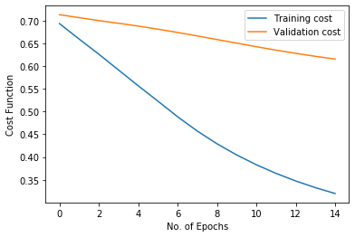

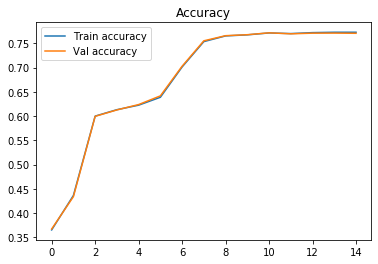

```python
# plot the results
plt.plot(train_costs3, label='Training cost')
plt.plot(validation_costs3, label='Validation cost')
plt.title('')
plt.xlabel('No. of Epochs')
plt.ylabel('Cost Function')
plt.legend()
plt.savefig("model3-trainval.png", dpi=300)
plt.show()

plt.plot(train_accuracies3, label='Train accuracy')
plt.plot(validation_accuracies3, label='Val accuracy')
plt.title('Accuracy')
plt.legend()
plt.show()
```

```python
test_report3 = my_score(model3, Xtest_PCA, Ytest)
test_cost3 = get_cost(model3, criterion3, Xtest_PCA, Ytest)
print(test_report3)
```

```
              precision    recall  f1-score   support

      Normal       0.61      0.95      0.74      9711
      Attack       0.94      0.54      0.68     12833

    accuracy                           0.71     22544
   macro avg       0.77      0.74      0.71     22544
weighted avg       0.79      0.71      0.71     22544
```

# Voting Systems

The models compares the following systems:

- Hard Voting
- Mixture of Experts
- Majority Function
- Weighted Average
- Majority System Based on Reliability

The Majority System Based on Reliability was used in the final model. Detailed explanations of the algorithmic systems and the reasoning behind each are explained in the [article](https://www.hindawi.com/journals/scn/2020/3512737/).